# Module 1 - Workshop 4

Author

Ben Barber

Published

27 July, 2026

# MB5370: Techniques in Marine Science 1: Programming Fundamentals

# Workshop 04. The Developer’s Toolbox & AI

# Introduction

This workshop focused on using AI-assisted coding tools and developing more advanced programming skills in R. I worked with conditional statements, pipes, data transformation and custom functions, while also learning how tools such as GitHub Copilot can support coding.

## Exercise: AI-Driven Data Visualisation Challenge

### Load Packages

```r
#install.packages("palmerpenguins")
library(tidyverse)
library(palmerpenguins)
```

## Instructing copliot example

Create a ggplot scatter plot using the penguins dataset. Plot bill_length_mm on the x-axis and bill_depth_mm on the y-axis.Colour points by species and use geom_point with size 3. Add a minimal theme and clean labels.

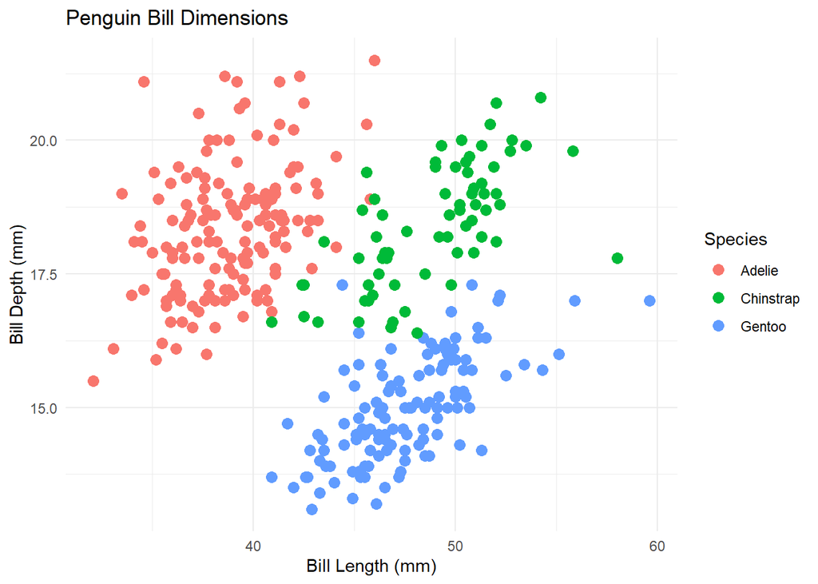

```r
ggplot(data = penguins) +
  geom_point(mapping = aes(x = bill_length_mm, y = bill_depth_mm, color = species), size = 3) +
  theme_minimal() +
  labs(title = "Penguin Bill Dimensions",
       x = "Bill Length (mm)",
       y = "Bill Depth (mm)",
       color = "Species")
```

## I’m Instructing

### Option A (Distribution Check)

create a ggplot boxplot using the penguins dataset.Plot flipper_length_mm on the y-axis and species on the x-axis.Facet the plot by island and use a custom color palette for the species.Add a title and clean labels.

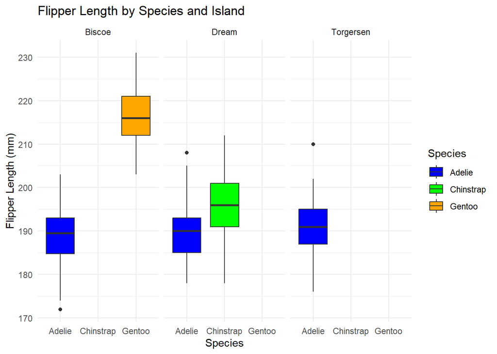

```r
ggplot(data = penguins) +
  geom_boxplot(mapping = aes(x = species, y = flipper_length_mm, fill = species)) +
  facet_wrap(~ island) +
  scale_fill_manual(values = c("Adelie" = "blue", "Chinstrap" = "green", "Gentoo" = "orange")) +
  labs(title = "Flipper Length by Species and Island",
       x = "Species",
       y = "Flipper Length (mm)",
       fill = "Species") +
  theme_minimal()
```

### Option B (Biomass Correlation)

Instruct Copilot to build a scatter plot mapping body_mass_g against flipper_length_mm, adding a linear regression trend line (geom_smooth) for each species.

create a ggplot scatter plot using the penguins dataset.Plot body_mass_g on the y-axis and flipper_length_mm on the x-axis. Add a linear regression trend line (geom_smooth) for each species.

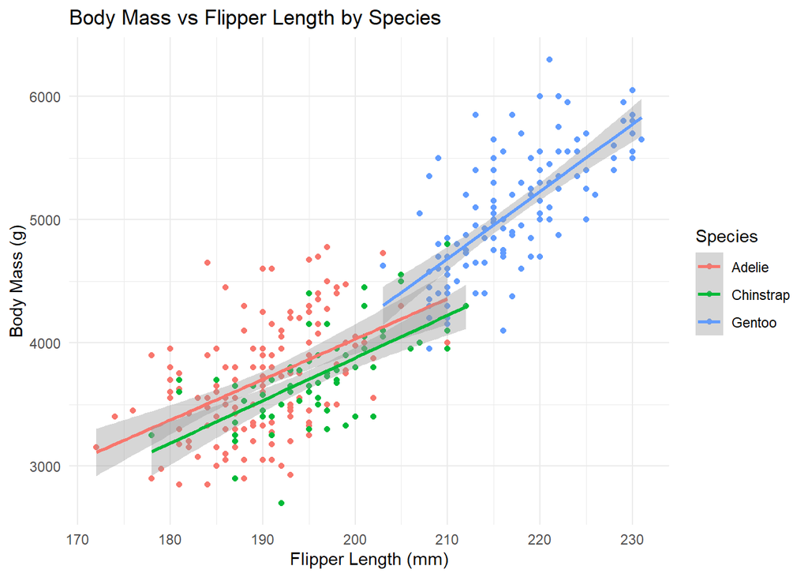

```r
ggplot(data = penguins) +
  geom_point(mapping = aes(x = flipper_length_mm, y = body_mass_g, color = species)) +
  geom_smooth(mapping = aes(x = flipper_length_mm, y = body_mass_g, color = species), method = "lm") +
  labs(title = "Body Mass vs Flipper Length by Species",
       x = "Flipper Length (mm)",
       y = "Body Mass (g)",
       color = "Species") +
  theme_minimal()
```

## chattr (Conversational Workspace Engine)

#### Downlaoding packages for chattr

```r
#install.packages("ellmer")
#install.packages("chattr")
```

#### Configuring chattr to model

```r
#usethis::edit_r_profile()

# Option A: For Google Gemini
#options(.chattr_chat = ellmer::chat_google_gemini())
```

this code snippet shows how to set up the chattr package to use Google’s Gemini model for conversational AI. By adding the line `options(.chattr_chat = ellmer::chat_google_gemini())` to your R profile, you configure chattr to utilize Gemini for generating responses in your conversational workspace. This allows you to leverage Gemini’s capabilities for tasks such as data analysis, code generation, and interactive discussions within your R environment.

### Exercise: Prompting for Context

Open your newly configured chattr interface using your keyboard shortcut. Paste a dataset summary or ask a conversational question to test the model delivery workflow. For example, prompt the interface with: “Show me how to load the built-in iris dataset and use ggplot2 to build a scatter plot of Sepal.Length versus Sepal.Width colored by Species.” Use the Copy to Document button to drop the code directly into an active R script and execute it.

#### My prompt

Create me a scatter plot using the iris dataset with ggplot2. I want a plot of the sepal length vs the sepal width. Colour the graph according to species

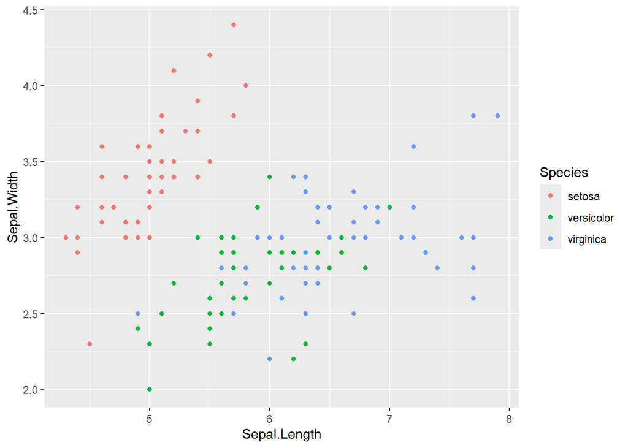

```r
library(ggplot2)

data(iris)

ggplot(iris, aes(x = Sepal.Length, y = Sepal.Width, color = Species)) +
  geom_point()
```

## Filtering your data

example:

```r
# Simple Example: Checking Sea Surface Temperature (SST)
sst <- 30.2

if (sst > 29.5) {
  print("Warning: Marine heatwave threshold exceeded!")
} else {
  print("SST remains within baseline parameters.")
}
```

```
[1] "Warning: Marine heatwave threshold exceeded!"
```

Base R: if and else The classic base R conditional structure screens a single value at a time. Its basic anatomy uses round brackets () for the logical condition and curly braces {} for the action if that condition is true.

### Tidyverse Alternative: Vectorised Conditionals (`dplyr`)

#### `if_else()`

The `if_else(condition, true_output, false_output)` function evaluates an entire column item by item.

#### `case_when()`

```r
# Load tidyverse (if not already loaded)
library(tidyverse)

# Sample coral data
coral_monitoring <- tibble(
  site = c("Site_A", "Site_B", "Site_C"),
  depth_m = c(12, 35, 8)
)

# Classify depth using if_else
coral_monitoring <- coral_monitoring %>%
  mutate(zone = if_else(depth_m > 30, "Deep Reef", "Shallow Reef"))
```

what do you think that function mutate() does? >The mutate() function from the dplyr package (part of the tidyverse) adds new columns to a data frame, or modifies existing ones, based on functions of existing columns. It’s a powerful tool for creating new variables or transforming existing ones.

What about the %>% symbol? Use your developing programmer skills to find out more information about these two functions and record your findings now in your qmd.

> The %>% symbol, known as the pipe operator (or forward pipe operator), loaded when you load dplyr or the tidyverse.Its primary purpose is to make code more readable and easier to write by chaining operations together. Instead of nesting function calls from the inside out, the pipe allows you to read code from left to right, passing the result of one function as the first argument to the next function. Consider the following:

function_c(function_b(function_a(data, arg1), arg2), arg3)

With the pipe operator, this becomes:

data %>% function_a(arg1) %>% function_b(arg2) %>% function_c(arg3)

This structure often makes the sequence of operations much clearer to follow.

```r
coral_monitoring <- coral_monitoring %>%
  mutate(reef_category = case_when(
    depth_m < 10  ~ "Lagoon / Flats",
    depth_m <= 30 ~ "Crest / Slope",
    depth_m > 30  ~ "Mesophotic / Deep",
    TRUE          ~ "Unclassified" # Catch-all remainder
  ))
```

```r
library(dplyr)
library(tibble)

marine_stations <- tibble(
  salinity = c(35, 28, 32, 12)
) %>%
  mutate(
    environment_type = case_when(
      salinity < 15 ~ "Estuarine",
      salinity >= 15 & salinity <= 30 ~ "Brackish",
      salinity > 30 ~ "Marine"
    )
  )

marine_stations
```

```
# A tibble: 4 × 2
  salinity environment_type
     <dbl> <chr>
1       35 Marine
2       28 Brackish
3       32 Marine
4       12 Estuarine
```

```r
# Using a standard for-loop
site_areas <- c(144, 400, 625)
results <- numeric(length(site_areas))

for (i in seq_along(site_areas)) {
  results[i] <- sqrt(site_areas[i])
}

results
```

```
[1] 12 20 25
```

```r
#Using the purrr equivalent:
library(purrr)
# Map directly and define your expected output type explicitly
mapped_results <- map_dbl(site_areas, sqrt)
mapped_results
```

```
[1] 12 20 25
```

Both examples produce the same result, but purrr makes the workflow shorter and cleaner. Using map_dbl() applies the function across the vector without needing a manual loop, making the code easier to read, reproduce, and scale for larger marine science datasets.

## Iterate a summary function over split lists of data

```r
iris %>%
  split(.$Species) %>%
  map(~summary(.x))
```

```
$setosa
  Sepal.Length    Sepal.Width     Petal.Length    Petal.Width
 Min.   :4.300   Min.   :2.300   Min.   :1.000   Min.   :0.100
 1st Qu.:4.800   1st Qu.:3.200   1st Qu.:1.400   1st Qu.:0.200
 Median :5.000   Median :3.400   Median :1.500   Median :0.200
 Mean   :5.006   Mean   :3.428   Mean   :1.462   Mean   :0.246
 3rd Qu.:5.200   3rd Qu.:3.675   3rd Qu.:1.575   3rd Qu.:0.300
 Max.   :5.800   Max.   :4.400   Max.   :1.900   Max.   :0.600
       Species
 setosa    :50
 versicolor: 0
 virginica : 0




$versicolor
  Sepal.Length    Sepal.Width     Petal.Length   Petal.Width          Species
 Min.   :4.900   Min.   :2.000   Min.   :3.00   Min.   :1.000   setosa    : 0
 1st Qu.:5.600   1st Qu.:2.525   1st Qu.:4.00   1st Qu.:1.200   versicolor:50
 Median :5.900   Median :2.800   Median :4.35   Median :1.300   virginica : 0
 Mean   :5.936   Mean   :2.770   Mean   :4.26   Mean   :1.326
 3rd Qu.:6.300   3rd Qu.:3.000   3rd Qu.:4.60   3rd Qu.:1.500
 Max.   :7.000   Max.   :3.400   Max.   :5.10   Max.   :1.800

$virginica
  Sepal.Length    Sepal.Width     Petal.Length    Petal.Width
 Min.   :4.900   Min.   :2.200   Min.   :4.500   Min.   :1.400
 1st Qu.:6.225   1st Qu.:2.800   1st Qu.:5.100   1st Qu.:1.800
 Median :6.500   Median :3.000   Median :5.550   Median :2.000
 Mean   :6.588   Mean   :2.974   Mean   :5.552   Mean   :2.026
 3rd Qu.:6.900   3rd Qu.:3.175   3rd Qu.:5.875   3rd Qu.:2.300
 Max.   :7.900   Max.   :3.800   Max.   :6.900   Max.   :2.500
       Species
 setosa    : 0
 versicolor: 0
 virginica :50
```

##Task using chattr## prompt: I have a list of three vectors containing fish count data. Write a for-loop to calculate the mean of each, and then show me the exact parallel way to do it using purrr’s map_dbl function.

```r
library(purrr)
library(dplyr)

# Create the list of vectors
fish_data <- list(
  vector1 = c(10, 12, 15, 11, 13),
  vector2 = c(5, 7, 6, 8, 9),
  vector3 = c(20, 22, 19, 21, 23)
)

# Using a for-loop
means_for_loop <- numeric(length(fish_data))
for (i in seq_along(fish_data)) {
  means_for_loop[i] <- mean(fish_data[[i]])
}

# Using purrr::map_dbl
means_map_dbl <- map_dbl(fish_data, mean)
```

```r
print(means_for_loop)
```

```
[1] 12.2  7.0 21.0
```

```r
print(means_map_dbl)
```

```
vector1 vector2 vector3
   12.2     7.0    21.0
```

```r
#comparing thee outputs we can see that both methods yield the same results, confirming that the purrr::map_dbl function is an efficient and cleaner alternative to the traditional for-loop for this type of operation.
```

## Writing custom functions

Function Construction Blueprint:

```r
# Function Definition
calculate_coral_mortality <- function(initial_count, surviving_count) {

  # Logic safety switch using our conditional tools!
  if (initial_count <= 0) {
    stop("Initial count must be greater than zero.")
  }

  mortality_rate <- (initial_count - surviving_count) / initial_count
  return(mortality_rate)
}

# Utilizing your custom function
calculate_coral_mortality(initial_count = 120, surviving_count = 84)
```

```
[1] 0.3
```

# Student Exercise 4: Custom Function Construction Task

Build a custom function named convert_temp_c_to_f that accepts a single argument representing temperature in Celsius. The function should perform the math conversion: F = (C * 9/5) + 32. Include a conditional safety check using an if statement that halts execution via stop() if the entered value is below absolute zero (-273.15 degrees Celsius). Test your function with both a valid temperature and an invalid value to ensure the error handling behaves as expected.

```r
# Define the custom function
convert_temp_c_to_f <- function(celsius_temp) {
  # Conditional safety check for absolute zero
  if (celsius_temp < -273.15) {
    stop("Temperature cannot be below absolute zero (-273.15 degrees Celsius).")
  }

  # Perform the conversion
  fahrenheit_temp <- (celsius_temp * 9 / 5) + 32
  return(fahrenheit_temp)
}

# Test with a valid temperature
valid_celsius <- 25
valid_fahrenheit <- convert_temp_c_to_f(valid_celsius)

# Test with an invalid temperature to ensure error handling
invalid_celsius <- -300
```

```r
convert_temp_c_to_f(120) # = 248
```

```
[1] 248
```

```r
convert_temp_c_to_f(-300) #Error in convert_temp_c_to_f(-300) : Temperature cannot be below absolute zero (-273.15 degrees Celsius).
```

```
Error in `convert_temp_c_to_f()`:
! Temperature cannot be below absolute zero (-273.15 degrees Celsius).
```

## Challenage 1

In real-world field surveys, calculations often depend on matching values across multiple lists or matrices. Read the documentation for purrr::map2_dbl(). Given a vector of raw survey counts counts <- c(15, 24, 8, 42) and a vector of species-specific scaling factors factors <- c(1.2, 0.8, 2.5, 1.1), write a mapping statement that iterates across both vectors simultaneously to return a single vector of scaled abundance values. Do not use a manual index loop.

```r
library(purrr)

# Define the vectors
counts <- c(15, 24, 8, 42)
factors <- c(1.2, 0.8, 2.5, 1.1)

# Use map2_dbl to iterate across both vectors simultaneously
scaled_abundance <- map2_dbl(counts, factors, ~ .x * .y)

scaled_abundance
```

```
[1] 18.0 19.2 20.0 46.2
```

## Challenge 2: The Robust Data Wrangling Pipeline Function

Create a custom function named clean_and_classify_survey that handles complex data frame structures. The function must fulfill these criteria: Accept a data frame and a column name threshold parameter as inputs. Safely check if the specified column name exists within the passed data frame; if it does not, trigger a user-friendly error message using stop(). Filter out rows containing missing values (NA) within that specific column. Use the pipe operator and mutate() along with a vectorised conditional (if_else() or case_when()) to append a status string variable classification based on your threshold parameter. Return the cleaned, altered data frame to the global environment. Test your custom pipeline using a mock tibble that contains at least one missing value to confirm your code handles anomalies without crashing.

```r
library(dplyr)
library(rlang) # Needed for !!sym() to handle string column names elegantly

# Define the custom function
clean_and_classify_survey <- function(df, col_to_check, threshold_value) {
  # 1. Safely check if the specified column name exists
  if (!col_to_check %in% names(df)) {
    stop(paste0("Error: Column '", col_to_check, "' not found in the data frame."))
  }

  # 2. Filter out rows with missing values (NA) in the specified column
  # 3. Use pipe operator and mutate() along with a vectorized conditional
  cleaned_df <- df %>%
    filter(!is.na(!!sym(col_to_check))) %>% # !!sym() allows using a string as a column name
    mutate(
      classification = if_else(
        !!sym(col_to_check) > threshold_value,
        "Above Threshold",
        "Below Threshold"
      )
    )

  # 4. Return the cleaned, altered data frame
  return(cleaned_df)
}
```

```r
# --- Test your custom pipeline ---

# Create a mock tibble with 2 missing values
mock_survey_data <- tibble(
  site = c("A", "B", "C", "D", "E"),
  species = c("Fish1", "Fish2", "Fish3", "Fish4", "Fish5"),
  count = c(10, NA, 25, 7, 18),
  biomass = c(100, 120, 150, NA, 110)
)

# Define a threshold value
my_threshold <- 15

# Test with valid inputs
cat("--- Testing with valid inputs ---\n")
```

```
--- Testing with valid inputs ---
```

```r
cleaned_classified_data <- tryCatch(
  {
    clean_and_classify_survey(mock_survey_data, "count", my_threshold)
  },
  error = function(e) {
    message("An error occurred: ", e$message)
    NULL
  }
)

# Show the result if successful
if (!is.null(cleaned_classified_data)) {
  print(cleaned_classified_data)
}
```

```
# A tibble: 4 × 5
  site  species count biomass classification
  <chr> <chr>   <dbl>   <dbl> <chr>
1 A     Fish1      10     100 Below Threshold
2 C     Fish3      25     150 Above Threshold
3 D     Fish4       7      NA Below Threshold
4 E     Fish5      18     110 Above Threshold
```

```r
# Test with an invalid column name to confirm error handling
cat("\n--- Testing with an invalid column name ---\n")
```

```
--- Testing with an invalid column name ---
```

```r
tryCatch(
  {
    clean_and_classify_survey(mock_survey_data, "non_existent_col", my_threshold)
  },
  error = function(e) {
    message("Successfully caught error: ", e$message)
  }
)
```

[output not shown]

this test confirms that the function correctly identifies when a specified column does not exist in the data frame and provides a user-friendly error message without crashing the entire script. The use of tryCatch allows us to handle the error gracefully and continue with other operations if needed.

# Workshop Reflection

This workshop showed me how AI can help generate and explain code, but also reinforced the importance of checking that the output is correct. I improved my understanding of conditional statements, pipes and functions, which will be useful for creating more efficient workflows when analysing marine science data.